# Model Matrix Mixed-Effects

### **NOTES ON STATISTICS, PROBABILITY and MATHEMATICS**

### Model Matrices in Mixed-Effects Models:

#### [QUESTION](http://stats.stackexchange.com/q/157851/67822):

In the `lmer` function within `lme4` in `R` there is a call for constructing a model matrix of random effects, $Z$, as explained [here](http://i.stack.imgur.com/BIcNCm.png), pages 7 - 9.

Calculating $Z$ entails KhatriRao and/or Kronecker products of two matrices, $J_i$ and $X_i$.

The matrix $J_i$ is a mouthful: “Indicator matrix of grouping factor indices”, but it seems to be a sparse matrix with dummy coding to select which unit (for example, subjects in repetitive measurements) corresponding to higher hierarchical levels are “on” for any observation. The $X_i$ matrix seems to act as a selector of measurements in the lower hierarchical level, so that the combination of both “selectors” would yield a matrix, $Z_i$ of the form illustrated in the paper via the following example:

```r
require(lme4)
```

```r
    (f<-gl(3,2))
```

```
## [1] 1 1 2 2 3 3
## Levels: 1 2 3
```

```r
    (Ji<-t(as(f,Class="sparseMatrix")))
```

```
## 6 x 3 sparse Matrix of class "dgCMatrix"
##      1 2 3
## [1,] 1 . .
## [2,] 1 . .
## [3,] . 1 .
## [4,] . 1 .
## [5,] . . 1
## [6,] . . 1
```

```r
    (Xi<-cbind(1,rep.int(c(-1,1),3L)))
```

```
##      [,1] [,2]
## [1,]    1   -1
## [2,]    1    1
## [3,]    1   -1
## [4,]    1    1
## [5,]    1   -1
## [6,]    1    1
```

Transposing each of these matrices, and performing a Khatri-Rao multiplication:

$\left[\begin{smallmatrix}1 & 1 &. &. &. &.\\.&.&1&1&.&.\\.&.&.&.&1&1 \end{smallmatrix}\right]\ast \left[\begin{smallmatrix}\,\,\,\,1 & 1 &\,\,\,\,1 &1 &\,\,\,\,1 &1\\-1&1&-1&1&-1&1 \end{smallmatrix}\right]= \left[\begin{smallmatrix}\,\,1 & 1 &.&.&.&.\\\,\,\,\,-1 &1&.&.&.&.\\ .&.&\,\,\,\,\,1 &1&.&.\\.&.&\,\,-1&1&.&.\\.&.&.&.&\,\,\,1&1\\.&.&.&.&-1&1 \end{smallmatrix}\right]$

But $Z_i$ is the transpose of it:

```r
(Zi<-t(KhatriRao(t(Ji),t(Xi))))
```

```
## 6 x 6 sparse Matrix of class "dgCMatrix"
##
## [1,] 1 -1 .  . .  .
## [2,] 1  1 .  . .  .
## [3,] .  . 1 -1 .  .
## [4,] .  . 1  1 .  .
## [5,] .  . .  . 1 -1
## [6,] .  . .  . 1  1
```

It turns out that the authors make use of the database `sleepstudy` in `lme4`, but don’t really elaborate on the design matrices as they apply to this particular study. So I’m trying to understand how the made up code in the paper reproduced above would translate into the more meaningful `sleepstudy` example.

For visual simplicity I have reduced the data set to just three subjects - “309”, “330” and “371”:

```r
    require(lme4)
    sleepstudy <- sleepstudy[sleepstudy$Subject %in% c(309, 330, 371), ]
    rownames(sleepstudy) <- NULL
```

Each individual would exhibit a very different intercept and slope should a simple OLS regression be considered individually, suggesting the need for a mixed-effect model with the higher hierarchy or unit level corresponding to the subjects:

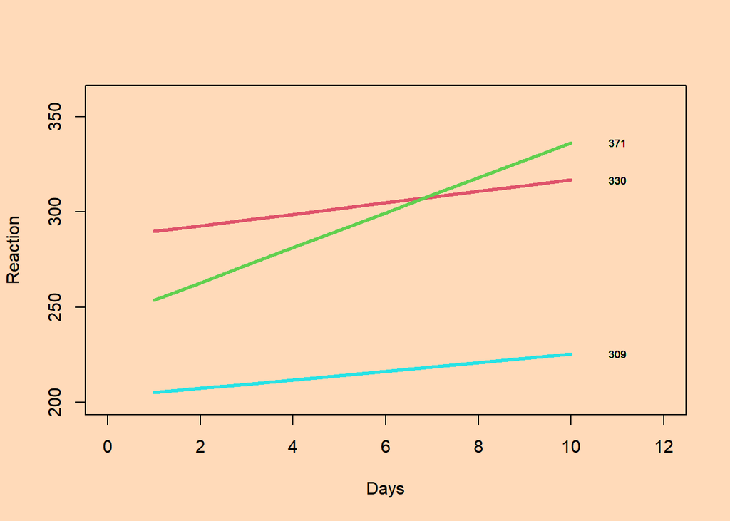

```r
        par(bg = 'peachpuff')
        plot(1,type="n", xlim=c(0, 12), ylim=c(200, 360),
                 xlab='Days', ylab='Reaction')
        for (i in sleepstudy$Subject){
                fit<-lm(Reaction ~ Days, sleepstudy[sleepstudy$Subject==i,])
                lines(predict(fit), col=i, lwd=3)
                text(x=11, y=predict(fit, data.frame(Days=9)), cex=0.6,labels=i)
        }
```

The mixed-effect regression call is:

```r
    fm1<-lmer(Reaction~Days+(Days|Subject), sleepstudy)
```

And the matrix extracted from the function yields the following:

[output not shown]

**But what are the actual** $J_i$ **and** $X_i$ **matrices and the corresponding** $Z_i= (J_i^{T}∗X_i^{T})^⊤$ **or** $Z_i= (J_i^{T}\otimes X_i^{T})^⊤$, **whichever is pertinent?**

Here is a possibility,

$\left[\begin{smallmatrix}1 & 1 & 1 & 1 & 1 & 1 & 1 & 1 &1&1&. &. &. &. &.& . &. &. &. &. &. &.&. & . &. &. &. &. &. &.\\ .&.&.&.&. & . &. &. &. &. &1 & 1 & 1 & 1 & 1 & 1 & 1 & 1 &1&1&.& . &. &. &. &. &. &.&.&.\\&. & . &. &. &. &. &. &.&. & . &. &. &. &. &.&.&.&.&.&1 & 1 & 1 & 1 & 1 & 1 & 1 & 1 &1&1\end{smallmatrix}\right]\ast \left[\begin{smallmatrix}1 & 1 & 1 & 1&1&1&1 & 1 & 1 & 1\\0&1&2&3&4&5&6&7&8&9 \end{smallmatrix}\right]=$

$\left[\begin{smallmatrix}1 & 1 & 1 &1&1&1&1&1&1&1&.&.&.&.&.&.&.&.&.&.&.&.&.&.&.&.&.&.&.&.\\0 & 1 & 2 &3&4&5&6&7&8&9&.&.&.&.&.&.&.&.&.&.&.&.&.&.&.&.&.&.&.&.\\.&.&.&.&&.&.&.&.&.&1 &1&1&1&1&1&1&1&1&1&.&.&.&.&.&.&.&.&.&.\\ &.&.&.&.&.&.&.&.&.&0 &1&2&3&4&5&6&7&8&9&.&.&.&.&.&.&.&.&.&.\\.&.&.&.&.&.&.&.&.&.&.&.&.&.&.&.&.&.&.&.&1&1&1&1&1&1&1&1&1&1\\&.&.&.&.&.&.&.&.&.&.&.&.&.&.&.&.&.&.&.&0&1&2&3&4&5&6&7&8&9 \end{smallmatrix}\right]$

The problem is that it is not the transposed as the `lmer` function seems to call for, and still is unclear what the rules are to create $X_i$.

####ANSWER:

1. Creating the $J_i$ matrix entails producing 3 levels (`309`, `330` and `371`) each one with 10 observations or measurements (`nrow(sleepstudy[sleepstudy$Subject==309,]) [1] 10`). Following the code in the original link in the OP:

```r
f <- gl(3,10)
Ji<-t(as(f,Class="sparseMatrix"))
```

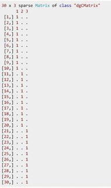

2. Building the $X_i$ matrix can be aided by using the function `getME` as a reference:

```r
   library(lme4)
  sleepstudy <- sleepstudy[sleepstudy$Subject %in% c(309, 330, 371), ]
  rownames(sleepstudy) <- NULL
  fm1<-lmer(Reaction~Days+(Days|Subject), sleepstudy)

Xi <- getME(fm1,"mmList")
```

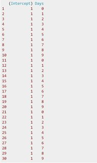

Since we will need the transpose, and the object `Xi` is not a matrix, the `t(Xi)` can be built as:

```r
t_Xi <- rbind(c(rep(1,30)),c(rep(0:9,3)))
```

3. $Z_i$ is calculated as $Z_i= (J_i^{T}∗X_i^{T})^⊤$:

```r
require(Matrix)
Zi<-t(KhatriRao(t(Ji),t_Xi))
```

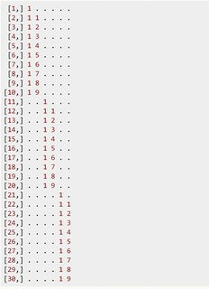

This corresponds to equation (6) in the original [paper](http://cran.r-project.org/web/packages/lme4/vignettes/lmer.pdf):

$$Z_i =
(J_i^T*X_i^T)^T=\begin{bmatrix}J_{i1}^T\otimes X_{i1}^T\\J_{i2}^T\otimes
X_{i2}^T\\\vdots\\J_{in}^T\otimes X_{in}^T\end{bmatrix}$$

And to see this we can instead play with truncated $J_i^T$ and $X_i^T$ matrices by imagining that instead of 9 measurements and a baseline (0), there is only 1 measurement (and a baseline). The resulting matrices would be:

$J_i^T=\left[\begin{smallmatrix}1&1&0&0&0&0\\0&0&1&1&0&0\\0&0&0&0&1&1\end{smallmatrix}\right]$ and $X_i^T=\left[\begin{smallmatrix}1&1&1&1&1&1\\0&1&0&1&0&1\end{smallmatrix}\right]$.

And

$J_i^T*X_i^T=\left[ \begin{smallmatrix} \left(\begin{smallmatrix}1\\0\\0\end{smallmatrix}\right)\otimes\left(\begin{smallmatrix}1\\0\end{smallmatrix}\right)&& \left(\begin{smallmatrix}1\\0\\0\end{smallmatrix}\right)\otimes\left(\begin{smallmatrix}1\\1\end{smallmatrix}\right)&& \left(\begin{smallmatrix}0\\1\\0\end{smallmatrix}\right)\otimes\left(\begin{smallmatrix}1\\0\end{smallmatrix}\right)&& \left(\begin{smallmatrix}0\\1\\0\end{smallmatrix}\right)\otimes\left(\begin{smallmatrix}1\\1\end{smallmatrix}\right)&& \left(\begin{smallmatrix}0\\0\\1\end{smallmatrix}\right)\otimes\left(\begin{smallmatrix}1\\0\end{smallmatrix}\right)&& \left(\begin{smallmatrix}0\\0\\1\end{smallmatrix}\right)\otimes\left(\begin{smallmatrix}1\\1\end{smallmatrix}\right) \end{smallmatrix} \right]$

$\small= \begin{bmatrix}J_{i1}^T\otimes X_{i1}^T && J_{i2}^T \otimes X_{i2}^T && J_{i3}^T\otimes X_{i3}^T && J_{i4}^T\otimes X_{i4}^T && J_{i5}^T\otimes X_{i5}^T && J_{i6}^T\otimes X_{i6}^T\end{bmatrix}$

$=\left[\begin{smallmatrix}1&1&0&0&0&0\\0&1&0&0&0&0\\0&0&1&1&0&0\\0&0&0&1&0&0\\0&0&0&0&1&1\\0&0&0&0&0&1\end{smallmatrix}\right]$. Which transposed and extended would result in $Z_i=\left[\begin{smallmatrix}1&0&0&0&0&0\\1&1&0&0&0&0\\1&2&0&0&0&0\\\vdots\\\\0&0&1&0&0&0\\0&0&1&1&0&0\\0&0&1&2&0&0\\\vdots\\\\0&0&0&0&1&0\\0&0&0&0&1&1\\0&0&0&0&1&2\\\\\vdots\end{smallmatrix}\right]$.

4. Extracting the $b$ vector of random effects coefficients can be done with the function:

```r
(b <- getME(fm1,"b"))
```

```
## 6 x 1 Matrix of class "dgeMatrix"
##             [,1]
## [1,] -44.1572587
## [2,]  -2.4118712
## [3,]  32.8629042
## [4,]  -0.3997979
## [5,]  11.2943545
## [6,]   2.8116691
```

If we add these values to the fixed-effects of the call `fm1<-lmer(Reaction~Days+(Days|Subject), sleepstudy)` we get the intercepts:

```
205.3016 for 309; 282.3223 for 330; and 260.7530 for 371
```

and the slopes:

```
2.407141 for 309; 4.419120 for 330; and 7.630739 for 371
```

values consistent with:

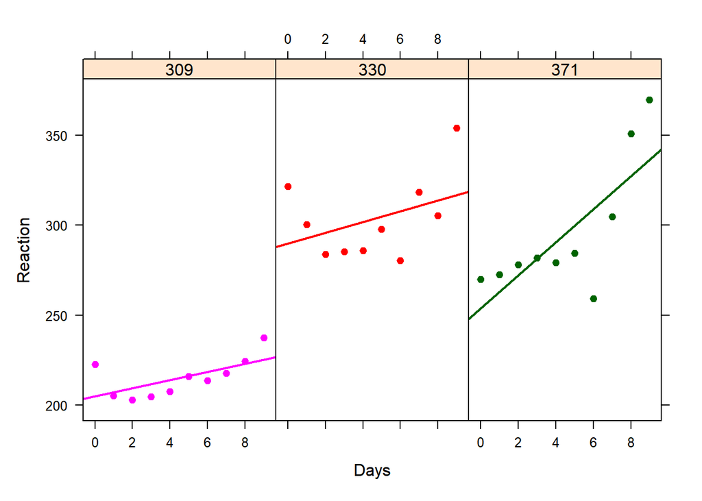

```r
    library(lattice)
    xyplot(Reaction ~ Days | Subject, groups = Subject, data = sleepstudy,
           pch=19, lwd=2, type=c('p','r'))
```

5. $Zb$ can be calculated as `as.matrix(Zi)%*%b`.

[Home Page](http://rinterested.github.io/statistics/index.html)

**NOTE: These are tentative notes on different topics for personal use - expect mistakes and misunderstandings.**